# Simulation Study: Bias and RMSE of IRT Equating Methods

Derek Briggs

2026-03-22

## 1 Motivation

In the companion tutorial (*IRT Equating using mirt*), we applied five equating methods to a single simulated NEAT dataset and found that every method underestimated the true standard deviation of the Group 2 ability distribution ($\sigma = 0.8$). The estimated SDs ranged from about 0.51 (mean-sigma) to 0.72 (concurrent calibration). Was this a fluke of one random dataset, or does it reflect a systematic tendency?

To find out, we repeat the simulation 100 times with the **same true item parameters** but freshly generated ability values and response data each time. For each replication we record the estimated Group 2 population mean and SD from each equating method, then summarize the results in terms of **bias** and **root mean squared error (RMSE)**.

## 2 Setup

We use the same item parameter configuration as the companion tutorial: two 20-item forms sharing 10 anchor items (items 1–10), with Group 1 abilities drawn from $N(0, 1)$ and Group 2 abilities from $N(0.5, 0.8)$. The item parameters are generated once and held fixed across all replications.

```r
library(mirt)
library(dplyr)
library(kableExtra)

# Generate fixed item parameters (same seed as companion tutorial)
set.seed(17)
b1 <- rnorm(20)
b2 <- c(b1[1:10], rnorm(10))
a1 <- runif(20, .5, 2)
a2 <- c(a1[1:10], runif(10, .5, 2))
d1 <- -a1 * b1
d2 <- -a2 * b2

# True Group 2 population parameters (our target)
true_mean <- 0.5
true_sd   <- 0.8
```

## 3 Helper Functions

We need the Stocking-Lord function from the companion tutorial and a wrapper that runs one complete replication.

```r
# 2PL ICC and TCC
icc_2pl <- function(theta, a, b) 1 / (1 + exp(-a * (theta - b)))
tcc_2pl <- function(theta, a, b) {
  sapply(theta, function(th) sum(icc_2pl(th, a, b)))
}

# Stocking-Lord linking
stocking_lord <- function(a1, b1, a2, b2,
                          theta = seq(-4, 4, by = 0.1),
                          start_A = NULL, start_B = NULL) {
  tcc_target <- tcc_2pl(theta, a1, b1)
  sl_criterion <- function(par) {
    A <- par[1]; B <- par[2]
    tcc_source <- tcc_2pl(theta, a2 / A, A * b2 + B)
    sum((tcc_target - tcc_source)^2)
  }
  if (is.null(start_A)) start_A <- mean(a2) / mean(a1)
  if (is.null(start_B)) start_B <- mean(b1) - start_A * mean(b2)
  result <- optim(c(start_A, start_B), sl_criterion, method = "Nelder-Mead")
  list(A = result$par[1], B = result$par[2])
}
```

The workhorse function below generates data, fits all five equating methods, and returns the estimated Group 2 mean and SD from each.

```r
run_one_rep <- function(a1, d1, a2, d2, n = 500) {
  # Generate new ability values
  th1 <- rnorm(n, 0, 1)
  th2 <- rnorm(n, 0.5, 0.8)

  # Simulate response data
  test1 <- as.data.frame(simdata(a = a1, d = d1, Theta = th1, itemtype = "dich"))
  test2 <- as.data.frame(simdata(a = a2, d = d2, Theta = th2, itemtype = "dich"))

  # --- Separate calibrations ---
  fit1 <- mirt(test1, 1, itemtype = "2PL", verbose = FALSE)
  fit2 <- mirt(test2, 1, itemtype = "2PL", verbose = FALSE)
  items1 <- coef(fit1, IRTpars = TRUE, simplify = TRUE)$items
  items2 <- coef(fit2, IRTpars = TRUE, simplify = TRUE)$items

  a1_anc <- items1[1:10, 1]; b1_anc <- items1[1:10, 2]
  a2_anc <- items2[1:10, 1]; b2_anc <- items2[1:10, 2]

  # Mean-mean
  A_mm <- mean(a2_anc) / mean(a1_anc)
  B_mm <- mean(b1_anc) - A_mm * mean(b2_anc)

  # Mean-sigma
  A_ms <- sd(b1_anc) / sd(b2_anc)
  B_ms <- mean(b1_anc) - A_ms * mean(b2_anc)

  # Stocking-Lord
  sl   <- stocking_lord(a1_anc, b1_anc, a2_anc, b2_anc)
  A_sl <- sl$A; B_sl <- sl$B

  # --- Anchored calibration ---
  anchor_a <- items1[1:10, 1]
  anchor_d <- -anchor_a * items1[1:10, 2]
  sv2 <- mirt(test2, 1, itemtype = "2PL", pars = "values", verbose = FALSE)
  sv2$value[sv2$name == "a1" & sv2$parnum < 41] <- anchor_a
  sv2$value[sv2$name == "d"  & sv2$parnum < 41] <- anchor_d
  sv2$est[sv2$parnum < 41] <- FALSE
  sv2$est[sv2$name == "MEAN_1"] <- TRUE
  sv2$est[sv2$name == "COV_11"] <- TRUE
  fit2.a   <- mirt(test2, 1, pars = sv2, verbose = FALSE)
  anc_mean <- coef(fit2.a)$GroupPars[1]
  anc_sd   <- sqrt(coef(fit2.a)$GroupPars[2])

  # --- Concurrent calibration ---
  test1c <- test1; test2c <- test2
  new_labels <- paste0("Item_", (ncol(test2c) + 1):(ncol(test2c) + 10))
  colnames(test2c)[(ncol(test2c) - 9):ncol(test2c)] <- new_labels
  test1c$group <- 1; test2c$group <- 2
  grp <- c(rep("Test1", n), rep("Test2", n))
  common_items <- paste0("Item_", 1:10)
  full_dat <- merge(test1c, test2c, by = c("group", common_items),
                    all.x = TRUE, all.y = TRUE)
  dat <- full_dat[, -1]
  cc     <- multipleGroup(dat, model = 1, group = grp, itemtype = "2PL",
                          invariance = c("intercepts", "slopes",
                                         "free_var", "free_means"),
                          verbose = FALSE)
  out.cc  <- coef(cc, simplify = TRUE, IRTpars = TRUE)
  cc_mean <- out.cc$Test2$means[1]
  cc_sd   <- sqrt(out.cc$Test2$cov[1])

  # Return results
  c(mm_mean = B_mm, mm_sd = A_mm,
    ms_mean = B_ms, ms_sd = A_ms,
    sl_mean = B_sl, sl_sd = A_sl,
    anc_mean = anc_mean, anc_sd = anc_sd,
    cc_mean = cc_mean, cc_sd = cc_sd)
}
```

## 4 Running the Simulation

We run 100 replications. Each replication generates new ability values and response data, holding the item parameters fixed.

```r
n_reps  <- 100
results <- matrix(NA, nrow = n_reps, ncol = 10)
colnames(results) <- c("mm_mean", "mm_sd", "ms_mean", "ms_sd",
                        "sl_mean", "sl_sd", "anc_mean", "anc_sd",
                        "cc_mean", "cc_sd")

set.seed(2026)
t_start <- Sys.time()

for (i in 1:n_reps) {
  out <- tryCatch(
    run_one_rep(a1, d1, a2, d2, n = 500),
    error = function(e) rep(NA, 10)
  )
  results[i, ] <- out
  if (i %% 100 == 0) cat("Replication", i, "of", n_reps, "\n")
}
```

```
## Replication 100 of 100
```

```r
t_end <- Sys.time()
cat("\nTotal time:", round(difftime(t_end, t_start, units = "mins"), 1), "minutes\n")
```

```
##
## Total time: 2.8 minutes
```

```r
cat("Failed replications:", sum(is.na(results[, 1])), "of", n_reps, "\n")
```

```
## Failed replications: 0 of 100
```

```r
results <- as.data.frame(results)
```

## 5 Results

### 5.1 Bias and RMSE

**Bias** is the average difference between the estimate and the true value (positive bias = overestimation). **RMSE** is the square root of the average squared error, combining bias and variability.

```r
# Remove any failed replications
res <- results[complete.cases(results), ]
n_valid <- nrow(res)

# Compute bias and RMSE for each method
methods <- c("Mean-Mean", "Mean-Sigma", "Stocking-Lord", "Anchored", "Concurrent")
mean_cols <- c("mm_mean", "ms_mean", "sl_mean", "anc_mean", "cc_mean")
sd_cols   <- c("mm_sd",   "ms_sd",   "sl_sd",   "anc_sd",   "cc_sd")

bias_mean <- sapply(mean_cols, function(x) mean(res[[x]] - true_mean))
bias_sd   <- sapply(sd_cols,   function(x) mean(res[[x]] - true_sd))
rmse_mean <- sapply(mean_cols, function(x) sqrt(mean((res[[x]] - true_mean)^2)))
rmse_sd   <- sapply(sd_cols,   function(x) sqrt(mean((res[[x]] - true_sd)^2)))

summary_tab <- data.frame(
  Method    = methods,
  Bias_Mean = round(bias_mean, 4),
  RMSE_Mean = round(rmse_mean, 4),
  Bias_SD   = round(bias_sd, 4),
  RMSE_SD   = round(rmse_sd, 4)
)

summary_tab |>
  kable("html",
        row.names = FALSE,
        col.names = c("Method",
                       "Bias", "RMSE",
                       "Bias", "RMSE")) |>
  kable_styling(full_width = FALSE) |>
  add_header_above(c(" " = 1,
                      "Group 2 Mean (true = 0.5)" = 2,
                      "Group 2 SD (true = 0.8)" = 2))
```

| Method | Group 2 Mean (true = 0.5) Bias | Group 2 Mean (true = 0.5) RMSE | Group 2 SD (true = 0.8) Bias | Group 2 SD (true = 0.8) RMSE |
| --- | --- | --- | --- | --- |
| Mean-Mean | -0.0007 | 0.1163 | 0.0016 | 0.0681 |
| Mean-Sigma | -0.0140 | 0.1207 | -0.0220 | 0.1313 |
| Stocking-Lord | -0.0115 | 0.0889 | -0.0044 | 0.0786 |
| Anchored | -0.0206 | 0.0837 | -0.0138 | 0.0674 |
| Concurrent | -0.0127 | 0.0841 | -0.0001 | 0.0668 |

[output not shown]

### 5.2 Sampling Distributions

The histograms below show the distribution of estimated Group 2 mean and SD across all replications. The dashed vertical line marks the true value.

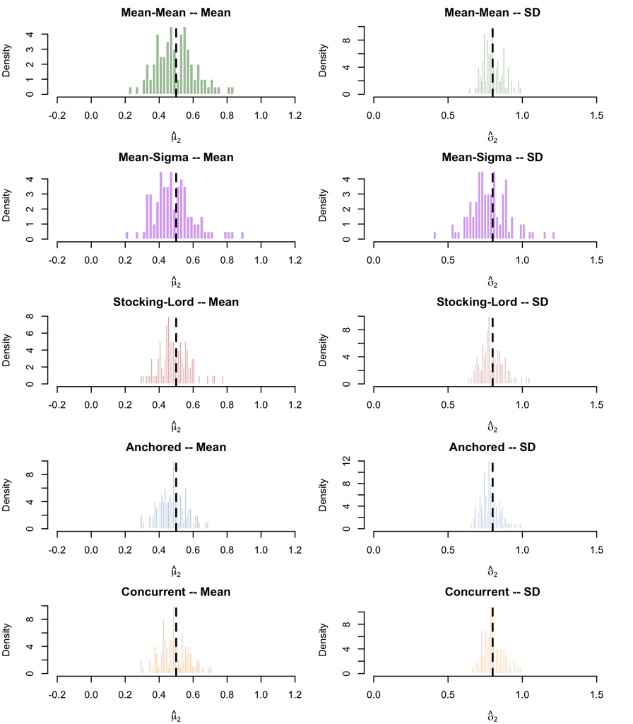

```r
par(mfrow = c(5, 2), mar = c(4, 4, 2, 1))
colors <- c("darkgreen", "purple", "firebrick", "steelblue", "darkorange")

for (j in seq_along(methods)) {
  # Mean
  hist(res[[mean_cols[j]]], breaks = 40, freq = FALSE,
       main = paste(methods[j], "-- Mean"),
       xlab = expression(hat(mu)[2]),
       col = adjustcolor(colors[j], alpha = 0.4), border = "white",
       xlim = c(-0.2, 1.2))
  abline(v = true_mean, lty = 2, lwd = 2)

  # SD
  hist(res[[sd_cols[j]]], breaks = 40, freq = FALSE,
       main = paste(methods[j], "-- SD"),
       xlab = expression(hat(sigma)[2]),
       col = adjustcolor(colors[j], alpha = 0.4), border = "white",
       xlim = c(0.0, 1.6))
  abline(v = true_sd, lty = 2, lwd = 2)
}
```

```r
par(mfrow = c(1, 1))
```

### 5.3 Summary Statistics Across Replications

```r
summ <- data.frame(
  Method     = rep(methods, 2),
  Parameter  = c(rep("Mean", 5), rep("SD", 5)),
  True       = c(rep(true_mean, 5), rep(true_sd, 5)),
  Median_Est = c(sapply(mean_cols, function(x) median(res[[x]])),
                 sapply(sd_cols,   function(x) median(res[[x]]))),
  Q25        = c(sapply(mean_cols, function(x) quantile(res[[x]], 0.25)),
                 sapply(sd_cols,   function(x) quantile(res[[x]], 0.25))),
  Q75        = c(sapply(mean_cols, function(x) quantile(res[[x]], 0.75)),
                 sapply(sd_cols,   function(x) quantile(res[[x]], 0.75)))
)

summ |>
  mutate(across(where(is.numeric), ~ round(.x, 3))) |>
  kable("html",
        col.names = c("Method", "Parameter", "True", "Median", "Q25", "Q75")) |>
  kable_styling(full_width = FALSE) |>
  collapse_rows(columns = 2, valign = "top")
```

|  | Method | Parameter | True | Median | Q25 | Q75 |
| --- | --- | --- | --- | --- | --- | --- |
| mm_mean | Mean-Mean | Mean | 0.5 | 0.494 | 0.413 | 0.565 |
| ms_mean |  | Mean | 0.5 | 0.466 | 0.410 | 0.543 |
| sl_mean |  | Mean | 0.5 | 0.481 | 0.440 | 0.542 |
| anc_mean |  | Mean | 0.5 | 0.480 | 0.422 | 0.535 |
| cc_mean |  | Mean | 0.5 | 0.483 | 0.429 | 0.544 |
| mm_sd | Mean-Mean | SD | 0.8 | 0.792 | 0.749 | 0.841 |
| ms_sd |  | SD | 0.8 | 0.761 | 0.703 | 0.862 |
| sl_sd |  | SD | 0.8 | 0.779 | 0.744 | 0.841 |
| anc_sd |  | SD | 0.8 | 0.778 | 0.743 | 0.825 |
| cc_sd |  | SD | 0.8 | 0.790 | 0.756 | 0.841 |

## 6 Discussion

The bias and RMSE results from 100 replications answer the motivating question: **is the underestimation of the Group 2 SD systematic, or a one-time fluke?**

Key findings to look for:

- **Mean recovery**: Which methods are approximately unbiased for the Group 2 mean? Which show the smallest RMSE?
- **SD recovery**: Is there systematic negative bias for the Group 2 SD across all methods? How severe is it, and which method is least biased?
- **Variability**: The RMSE captures both bias and sampling variability. A method with small bias but large variability may have worse RMSE than a slightly biased but stable method.
- **Mean-sigma instability**: The sampling distribution of the mean-sigma estimates likely shows much wider spread (higher RMSE) than the other methods, consistent with the sensitivity to extreme $\hat{b}$ values we observed in the companion tutorial.

In the psychometric literature, Kolen and Brennan (2014, Section 6.3.4) report that the characteristic curve methods (Stocking-Lord, Haebara) produce more stable results than the moment-based methods (mean-mean, mean-sigma), and that concurrent calibration tends to outperform separate calibration when the IRT model fits the data. The results of this simulation allow us to evaluate these claims in a concrete setting.

## 7 On Your Own

1. Examine the bias and RMSE table. Is the negative bias in the SD estimate a property of all methods, or just some? What does this tell us about the difficulty of recovering the population variance from this particular set of anchor items?
2. Which method has the best overall performance (considering both mean and SD recovery)? Is there a clear winner, or does it depend on what you prioritize?
3. Try increasing the sample size from 500 to 2,000 per group. Does the SD bias decrease? What about the RMSE?
4. Try reducing the anchor set to 5 items (e.g., items 1–5). How does this affect the bias and RMSE of each method?
5. The item parameters were generated randomly and may not be ideal for equating purposes. What properties would you want in a set of anchor items to get the best equating results?